# DS002R Projects Presentation

May 13, 2025

Devi Canseco

# TidyTuesday

## Groundhog Day Predictions

- TidyTuesday’s January 30, 2024
- Looking at the spring arrival predictions from groundhogs across America and Canada
- Have predictions increased over the years, and do they lean towards one prediction result?
- Which groundhog is contributing to the results?

## Increasing Predictions

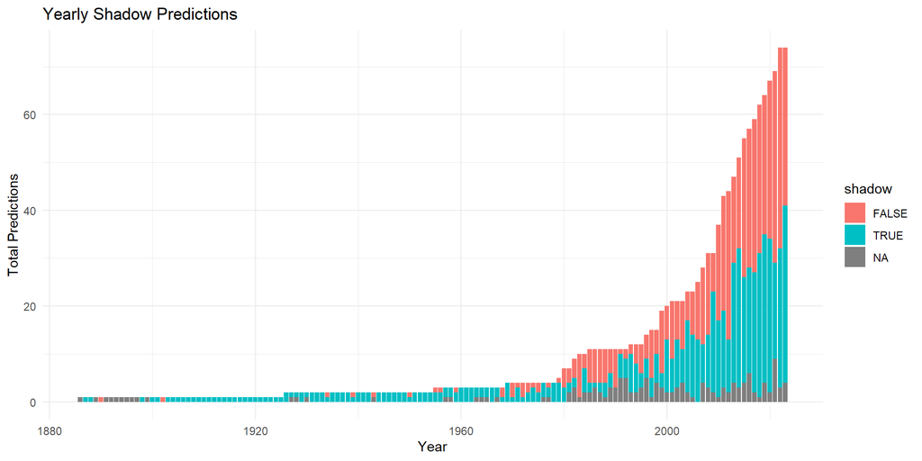

## Groundhog Contribution

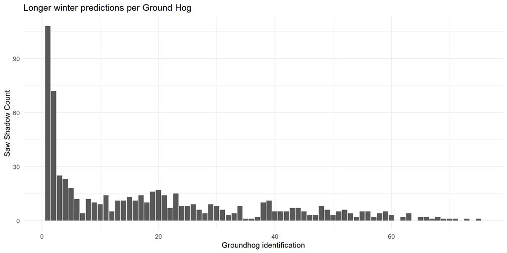

## The Simpsons’s Script

- TidyTuesday folder for February 2, 2025
- Looking at characters with over 2000 cumulative word counts.
- How is line distribution decided based on a character’s role?

## Character word count

[figure not shown]

## Conclusions

- Main character, main cast, popular side characters
- Would the results be surprising to a fan? Can it be used to gain insight into popularity?

# Risk Profile

- TidyTuesday January 23, 2024
- Comparing education scores in medium-sized vs small-sized towns
- Is there a significant difference in education scores between different-sized towns?

## Repeated Permutation

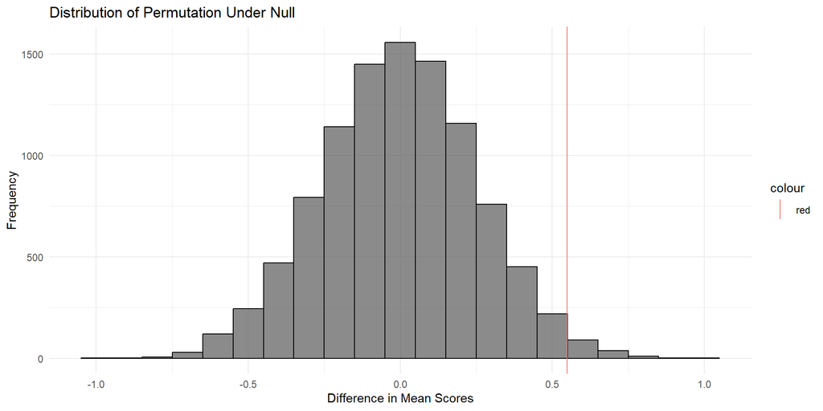

## Conclusions

- P-value = 0.0139
- There is a significant difference between education scores of medium-sized and small-sized towns

# SQL Drivers

## Florida vs California

- Stanford Open Policing Project
- Comparing Florida’s and California’s proportion of total citations issued per total stops.
- Which state has better drivers?

## Proportion

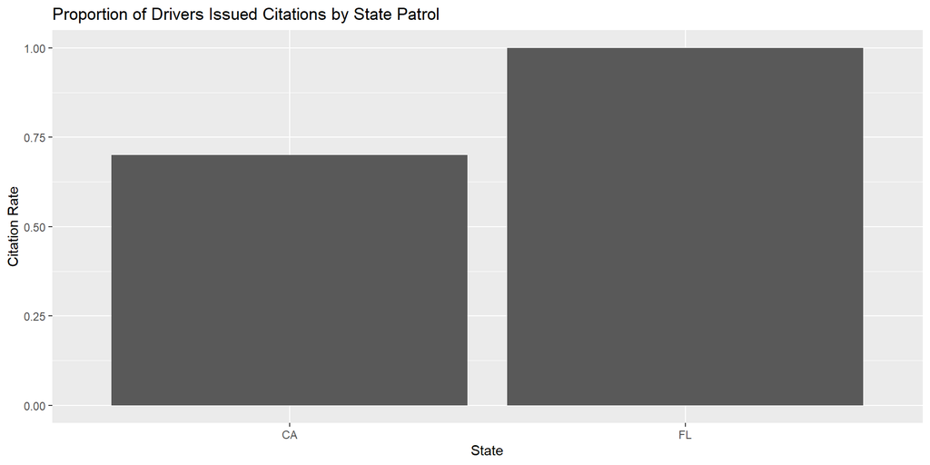

## Conclusions

- Not a determinant of good drivers, but fun speculation of the causes for the difference.
- Skill of the drivers or police attitude?